# A Data-Driven Study of Loan Approval

#### Scaling data

```r
data_kmeans_scaled <- scale(data_kmeans)
```

#### Deciding on optimal number of clusters using elbow plot

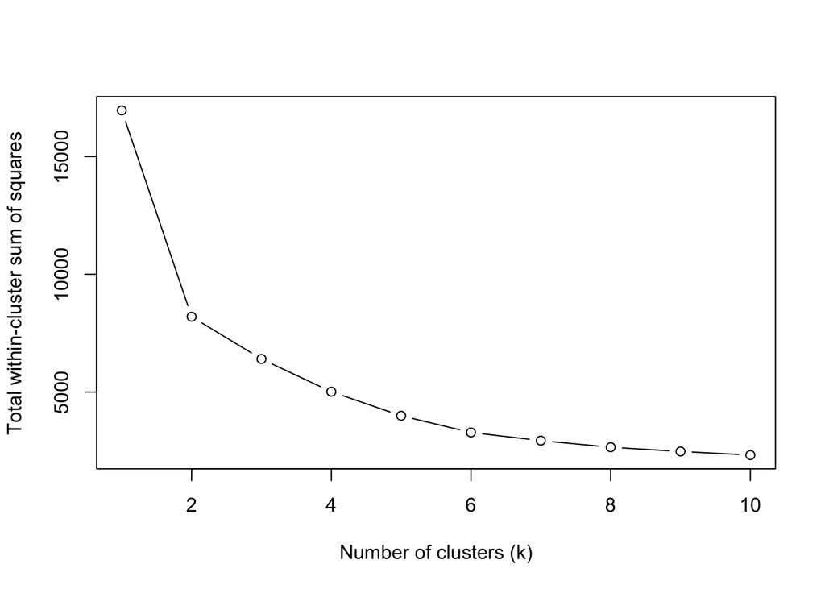

```r
wss <- sapply(1:10, function(k){
  kmeans(data_kmeans_scaled, k, nstart = 20)$tot.withinss
})

plot(1:10, wss, type = "b",
     xlab = "Number of clusters (k)",
     ylab = "Total within-cluster sum of squares")
```

The elbow plot indicates a distinct inflection point at `k = 2`, which supports selecting two clusters for the analysis.

#### Run k-means with k=2

```r
set.seed(123)
k <- 2

km <- kmeans(data_kmeans_scaled, centers = k, nstart = 25)
```

#### Calculating silhouette score of the cluster

```r
library(cluster)

sil <- silhouette(km$cluster, dist(data_kmeans_scaled))
mean(sil[, 3])
```

```
## [1] 0.423
```

The silhouette score of 0.423 indicates that the two borrower clusters are reasonably well-separated, meaning the clustering has captured meaningful differences in income, assets, loan amount, and CIBIL score. While the groups are not perfectly distinct, the separation is strong enough to provide useful insights into different borrower profiles.

#### Creating cluster profiles

Attaching cluster labels to both the scaled and original datasets, then calculating the average unscaled feature values for each cluster to create interpretable cluster profiles.

```r
# df_scaled already contains cluster labels
df_scaled <- as.data.frame(data_kmeans_scaled)
df_scaled$cluster <- factor(km$cluster)

# -----------------------
# 1. Add cluster labels to ORIGINAL data
# -----------------------
df_unscaled <- data_kmeans      # original (unscaled) data
df_unscaled$cluster <- factor(km$cluster)

# -----------------------
# 2. Compute cluster profiles using unscaled values
# -----------------------
cluster_profiles_unscaled <- df_unscaled %>%
  group_by(cluster) %>%
  summarise(
    loan_amount = mean(loan_amount),
    cibil_score = mean(cibil_score),
    income_annum = mean(income_annum),
    combined_asset_value = mean(combined_asset_value)
  )

print(cluster_profiles_unscaled)
```

```
## # A tibble: 2 × 5
##   cluster loan_amount cibil_score income_annum combined_asset_value
##   <fct>         <dbl>       <dbl>        <dbl>                <dbl>
## 1 1         22662709.        594.     7510627.            48803207.
## 2 2          7913197.        606.     2709201.            17009944.
```

#### Cluster interpretation

- **Cluster 1: High-value borrowers:** This cluster represents financially strong borrowers who request very large loans and possess significant asset holdings and high annual income. Despite having slightly lower CIBIL scores on average, their high net worth and strong cash flow make them lower risk from a collateral perspective.
- **Cluster 2: Moderate-value borrowers:** This cluster consists of moderate-income, moderate-asset borrowers who apply for smaller loans and have slightly better credit scores. Their financial profile is less substantial than Cluster 1, but their stronger CIBIL scores might indicate better repayment discipline.

These differences suggest that the clustering effectively separates borrowers based on financial strength and borrowing patterns.